# Восполнение пропущенных значений

Oksana Plastinina

2026-01-16

```r
library(tidyverse)
```

```r
library(ggplot2)
library(ggResidpanel)
library(ggfortify)
library(mice)
library(lmtest)
library(sandwich)
library(flextable)
thememine <- theme(
  plot.title = element_text(size = 15, hjust = 0.5),
  plot.subtitle = element_text(size = 16, hjust = 0.5),
  axis.title = element_text(size = 12),
  axis.text = element_text(size = 9, colour = 'grey10'),
  panel.background = element_rect(fill = 'white'),
  panel.grid = element_line(colour = 'grey90')
)

theme_set(thememine)
```

```r
data <- read.csv('data.csv')
```

```r
#меняем тип некотрых переменных, создаем перменную ИМТ
data <- data %>%
  mutate(
    male = as.factor(male),
    insulin = as.factor(insulin),
    bmi = weight/ (height/100)^2
  )

# summary(data)
```

# 1 **Модель 1. Оценка ассоциации ИМТ с уровнем гликированного гемоглобина**

Исходя из графика взаимосвязи ИМТ и уровня гликированного гемоглобина, переменные имеют небольшую позитивную ассоциацию.

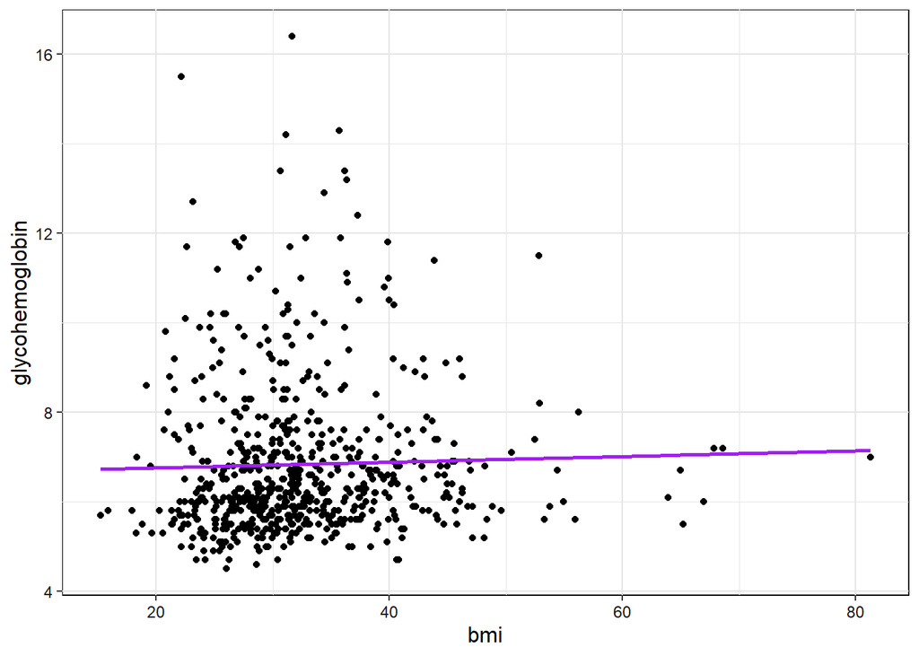

```r
data %>%
  ggplot(aes(y = glycohemoglobin, x = bmi))+
  geom_point()+
  geom_smooth(method = 'lm', se = F, colour = 'purple')
```

Количественно связь между ИМТ и уровнем гликированного гемоглобина оценивали с помощью линейной регрессии, построенной методом наименьших квадратов.

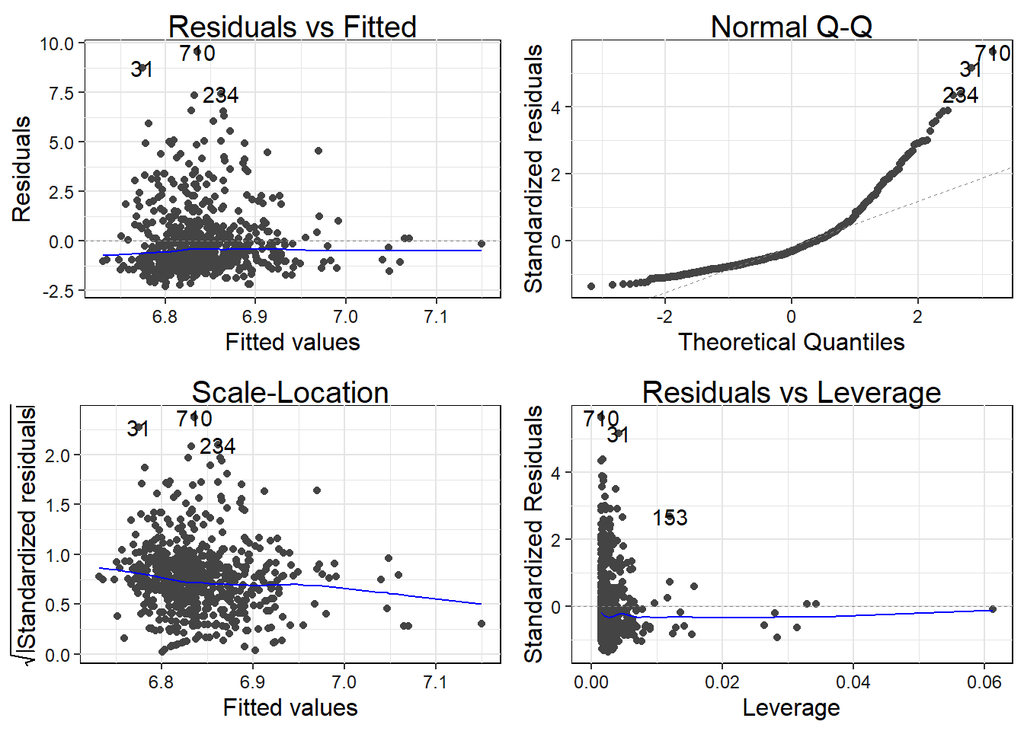

```r
fit1 <- lm(glycohemoglobin ~ bmi, data)

autoplot(fit1)
```

```r
summary(fit1)
```

```
##
## Call:
## lm(formula = glycohemoglobin ~ bmi, data = data)
##
## Residuals:
##     Min      1Q  Median      3Q     Max
## -2.2998 -1.0791 -0.5191  0.4753  9.5643
##
## Coefficients:
##             Estimate Std. Error t value Pr(>|t|)
## (Intercept) 6.634700   0.282814  23.460   <2e-16 ***
## bmi         0.006343   0.008483   0.748    0.455
## ---
## Signif. codes:  0 '***' 0.001 '**' 0.01 '*' 0.05 '.' 0.1 ' ' 1
##
## Residual standard error: 1.696 on 651 degrees of freedom
##   (261 observations deleted due to missingness)
## Multiple R-squared:  0.0008582,  Adjusted R-squared:  -0.0006766
## F-statistic: 0.5592 on 1 and 651 DF,  p-value: 0.4549
```

```r
coeftest(fit1, vcov. = vcovHC, conf.int = TRUE) %>%
  broom::tidy()
```

```
## # A tibble: 2 × 5
##   term        estimate std.error statistic   p.value
##   <chr>          <dbl>     <dbl>     <dbl>     <dbl>
## 1 (Intercept)  6.63      0.253      26.2   5.44e-104
## 2 bmi          0.00634   0.00733     0.865 3.87e-  1
```

```r
# 0.006343161 + 1.96*0.007334987
# 0.006343161 - 1.96*0.007334987
```

В связи с ненормальным распределением остатков модели, стандарные ошибки оценивали с использованием робастных стандартных ошибки по Хубера-Уайта типа HC3.

Согласно полученой линейной модели заивисимости уровня гликированного гемоглобина от ИМТ, увеличение ИМТ на 1 кг/м^2 статистически не значимо увеличивает уровень гликированного гемоглобина на 0,006% п.п. (95% ДИ [-0.008; 0.021], р-значение = 0.38).

Однаков, в процессе анализа теряется 261 наблюдений (28.6% от всех наблюдений), что может исказить полученную оценку.

# 2 **Модель 2. Оценка ассоциации ИМТ с уровнем гликированного гемоглобина в зависимости от применения препаратов инсулина**

Исходя из графика взаимосвязи ИМТ и уровня гликированного гемоглобина в зависимости от применения препаратов инсулина, группы имеют разное направление ассоциации: пациенты, принимающие инсулин имеют небольшую отрицательную ассоциации, пациенты не примнимающие - небольшую положительную.

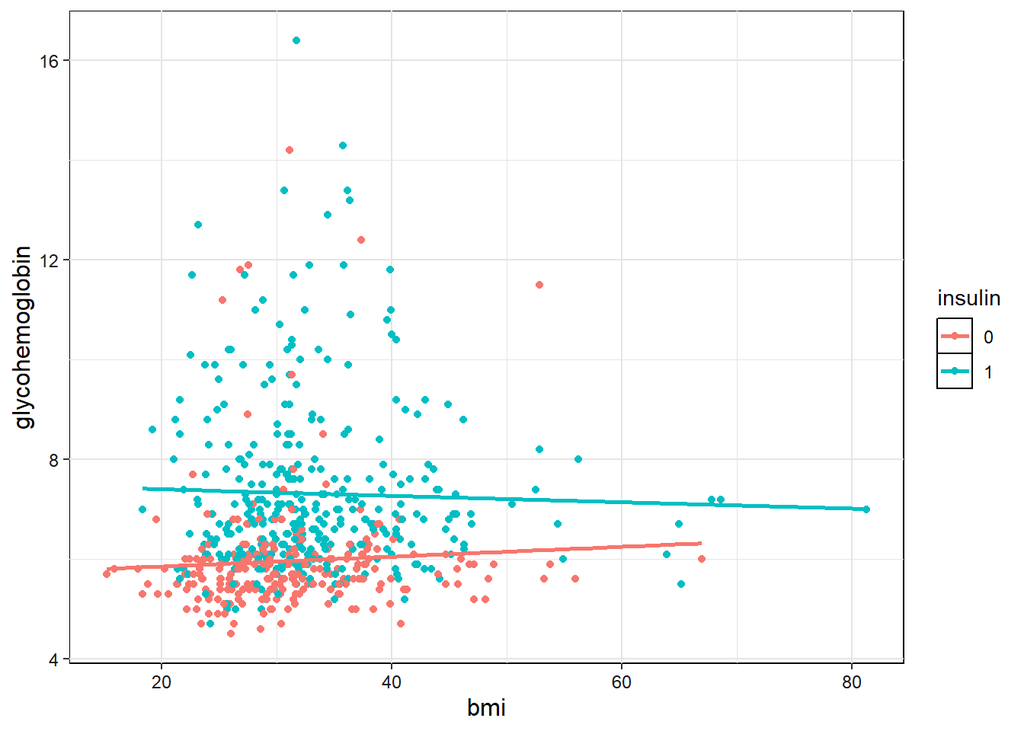

```r
data %>%
  filter(!is.na(insulin)) %>%
  ggplot(aes(y = glycohemoglobin, x = bmi, colour = insulin))+
  geom_point()+
  geom_smooth(method = 'lm', se = F)
```

Количественно связь между ИМТ и уровнем гликированного гемоглобина в зависимости от применения препаратов инсулина оценивали с помощью линейной регрессии, построенной методом наименьших квадратов.

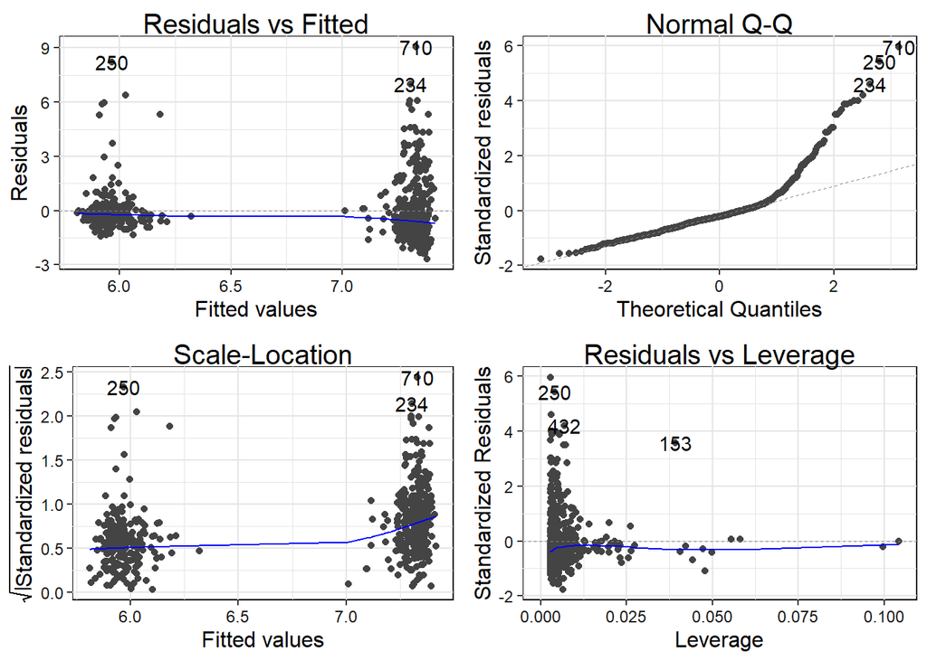

```r
fit2 <- lm(glycohemoglobin ~ bmi*insulin, data)

autoplot(fit2)
```

```r
summary(fit2)
```

```
##
## Call:
## lm(formula = glycohemoglobin ~ bmi * insulin, data = data)
##
## Residuals:
##     Min      1Q  Median      3Q     Max
## -2.6783 -0.8491 -0.3282  0.2676  9.0698
##
## Coefficients:
##              Estimate Std. Error t value Pr(>|t|)
## (Intercept)   5.66093    0.42112  13.443  < 2e-16 ***
## bmi           0.00986    0.01315   0.750 0.453470
## insulin1      1.87272    0.54406   3.442 0.000618 ***
## bmi:insulin1 -0.01628    0.01657  -0.983 0.326075
## ---
## Signif. codes:  0 '***' 0.001 '**' 0.01 '*' 0.05 '.' 0.1 ' ' 1
##
## Residual standard error: 1.522 on 584 degrees of freedom
##   (326 observations deleted due to missingness)
## Multiple R-squared:  0.1626, Adjusted R-squared:  0.1583
## F-statistic: 37.79 on 3 and 584 DF,  p-value: < 2.2e-16
```

```r
coeftest(fit2, vcov. = vcovHC, conf.int = TRUE) %>%
  broom::tidy()
```

```
## # A tibble: 4 × 5
##   term         estimate std.error statistic  p.value
##   <chr>           <dbl>     <dbl>     <dbl>    <dbl>
## 1 (Intercept)   5.66       0.343     16.5   1.38e-50
## 2 bmi           0.00986    0.0111     0.888 3.75e- 1
## 3 insulin1      1.87       0.458      4.09  4.88e- 5
## 4 bmi:insulin1 -0.0163     0.0138    -1.18  2.40e- 1
```

```r
# 0.009860495 + 1.96*0.01110287
# 0.009860495 - 1.96*0.01110287
#
# 1.872723369 + 1.96*0.45767046
# 1.872723369 - 1.96*0.45767046
#
# -0.016282995 - 1.96*0.01384291
# -0.016282995 + 1.96*0.01384291
```

В связи с ненормальным распределением остатков модели и их гетероскедастичность, стандарные ошибки оценивали с использованием робастных стандартных ошибки по Хубера-Уайта типа HC3.

Согласно полученой линейной модели зависимости уровня гликированного гемоглобина от ИМТ с учетом применения препаратов инсулина:

1. увеличение ИМТ на 1 кг/м^2 статистически не значимо увеличивает уровень гликированного гемоглобина на 0,010% п.п. (95% ДИ [-0.011; 0.032], р-значение = 0.37).
2. Прием препаратов инсулина статистически значимо повышает уровень гликированного гемоглобина 1.87% п.п. (95% ДИ [0.98; 2.77], р-значение = 4.88 × 10⁻⁵).
3. наблюдается статистически незначимый эффект группы: эффект имт статистически не значимо различается между группами пациентов принимающих и не принимаюх инсулин на на -0,016% п.п. (95% ДИ [-0,043; 0.011], р-значение = 0.24).

Однаков, в процессе анализа теряется 326 наблюдений (35.7% от всех наблюдений), что может исказить полученную оценку.

# 3 **Модель 3: Оценка ассоциации ИМТ с уровнем гликированного гемоглобина в зависимости от применения препаратов инсулина с контролем пола и возраста**

Исходя из графика видно, что уровень гликированного гемоглобина у мужчин и женщин распределен одинаково, уровень гликированного гемоглобина выше у пациентов, принимающих препараты инсулина вне заивисимости от пола.

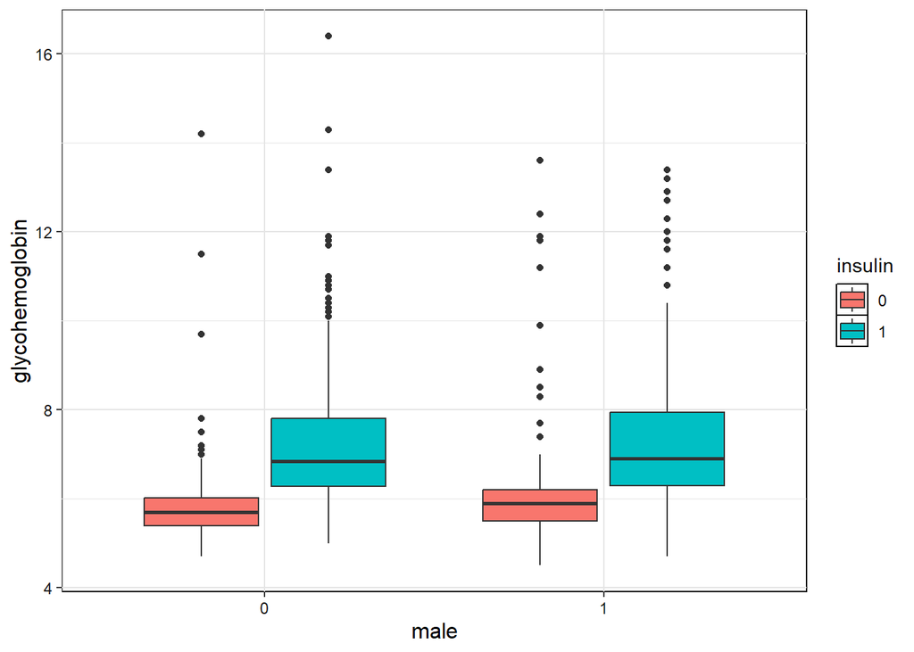

```r
data %>%
  filter(!is.na(insulin)) %>%
  ggplot()+
  geom_boxplot(aes(y = glycohemoglobin, x = male, fill = insulin))
```

Исходя из графика взаимосвязи ИМТ и уровня гликированного гемоглобина в зависимости от пола, обе группы имеют небольшую положительную ассоциацию данных переменных.

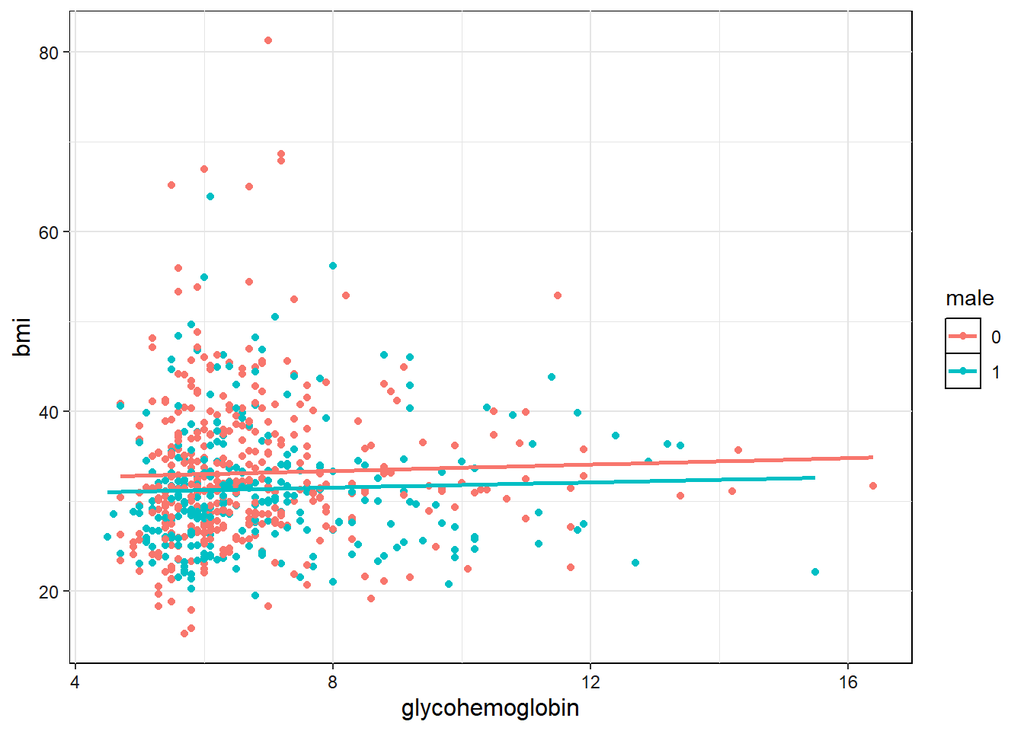

```r
data %>%
  ggplot(aes(x = glycohemoglobin, y = bmi, colour = male))+
  geom_point()+
  geom_smooth(method = 'lm', se = F)
```

Исходя из графика взаимосвязи возраста и уровня гликированного гемоглобина в зависимости от приема препаратов инсулина две группы имеют разные направления ассоциации: пациенты, принимающие инсулин имеют небольшую отрицательную ассоциацию, пациенты не принимающие - небольшую положительную.

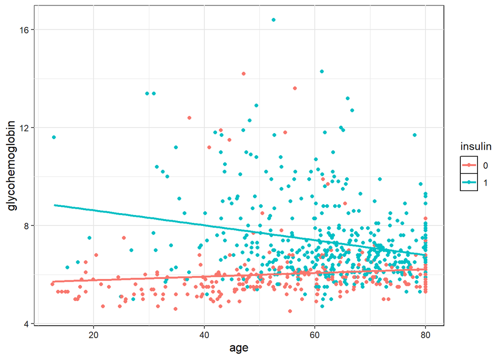

```r
data %>%
  filter(!is.na(insulin)) %>%
  ggplot(aes(y = glycohemoglobin, x = age, colour = insulin))+
  geom_point()+
  geom_smooth(method = 'lm', se = F)
```

Количественно связь между ИМТ и уровнем гликированного гемоглобина с учетом факторов возраста и пола оценивали с помощью линейной регрессии, построенной методом наименьших квадратов.

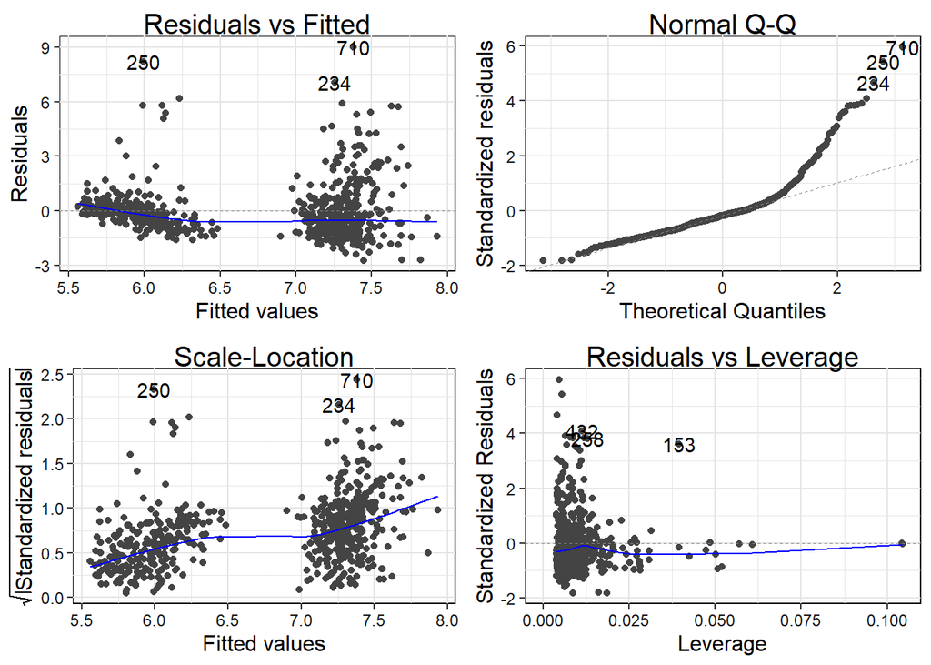

```r
fit3 <- lm(glycohemoglobin ~ bmi*insulin + male + age, data)

autoplot(fit3)
```

```r
summary(fit3)
```

```
##
## Call:
## lm(formula = glycohemoglobin ~ bmi * insulin + male + age, data = data)
##
## Residuals:
##     Min      1Q  Median      3Q     Max
## -2.7500 -0.8902 -0.2719  0.3258  9.0184
##
## Coefficients:
##               Estimate Std. Error t value Pr(>|t|)
## (Intercept)   6.316425   0.513295  12.306  < 2e-16 ***
## bmi           0.005651   0.013285   0.425 0.670717
## insulin1      1.874573   0.541754   3.460 0.000579 ***
## male1         0.101705   0.129546   0.785 0.432722
## age          -0.010609   0.004178  -2.539 0.011366 *
## bmi:insulin1 -0.013590   0.016532  -0.822 0.411389
## ---
## Signif. codes:  0 '***' 0.001 '**' 0.01 '*' 0.05 '.' 0.1 ' ' 1
##
## Residual standard error: 1.516 on 582 degrees of freedom
##   (326 observations deleted due to missingness)
## Multiple R-squared:  0.1725, Adjusted R-squared:  0.1654
## F-statistic: 24.27 on 5 and 582 DF,  p-value: < 2.2e-16
```

```r
coeftest(fit3, vcov. = vcovHC, conf.int = TRUE) %>%
  broom::tidy()
```

```
## # A tibble: 6 × 5
##   term         estimate std.error statistic  p.value
##   <chr>           <dbl>     <dbl>     <dbl>    <dbl>
## 1 (Intercept)   6.32      0.459      13.8   1.43e-37
## 2 bmi           0.00565   0.0115      0.490 6.24e- 1
## 3 insulin1      1.87      0.464       4.04  6.04e- 5
## 4 male1         0.102     0.133       0.767 4.43e- 1
## 5 age          -0.0106    0.00409    -2.60  9.67e- 3
## 6 bmi:insulin1 -0.0136    0.0141     -0.964 3.35e- 1
```

```r
# 0.005651093 + 1.96*0.011526160
# 0.005651093 - 1.96*0.011526160
#
# 1.874572954 + 1.96*0.463894969
# 1.874572954 - 1.96*0.463894969
#
# -0.013590301 - 1.96*0.014092220
# -0.013590301 + 1.96*0.014092220
```

В связи с ненормальным распределением остатков модели и их гетероскедастичность, стандарные ошибки оценивали с использованием робастных стандартных ошибки по Хубера-Уайта типа HC3.

Однаков, в процессе анализа теряется 326 наблюдений (35.7% от всех наблюдений), что может исказить полученную оценку.

# 4 **ИМпутация с NA**

В связи с высокой долей пропущенных данных в анализах: 28.6% от всех наблюдений в модели 1 и 35.7 % в моделях 2 и 3 - для уточнения данных приняли решение провести анализ паттернов пропусков.

Анализ паттерно пропусков проводили визуально. Исходя из рисунка видна зависимость пропусков, примерно половина пропусков перменной уровня гликированного гемоглобина связана с пропусками в переменной ИМТ (наблюдения роста и веса соответвенно). Такой паттер исключает механизм MCAR и свидетельствует скорее о MAR.

Клинически эта картинка объяснима, пациенты не пропускающие прием, где происходит замер роста и веса, соотвественно пропустят назначение и сдачу анализов, в том числе на уровень гликированного гемоглобина.

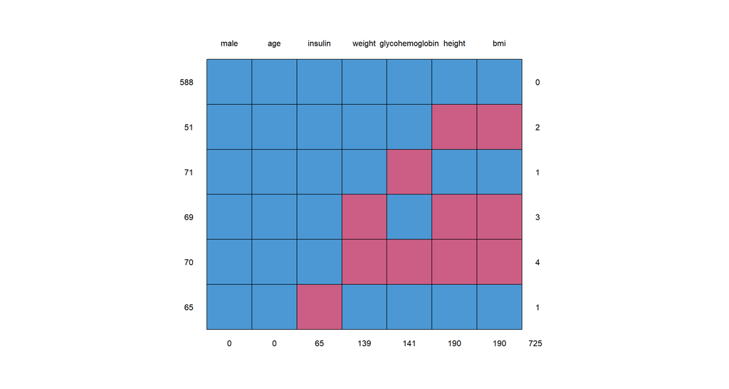

```
##     male age insulin weight glycohemoglobin height bmi
## 588    1   1       1      1               1      1   1   0
## 51     1   1       1      1               1      0   0   2
## 71     1   1       1      1               0      1   1   1
## 69     1   1       1      0               1      0   0   3
## 70     1   1       1      0               0      0   0   4
## 65     1   1       0      1               1      1   1   1
##        0   0      65    139             141    190 190 725
```

```r
mice::md.pattern(data
                 # %>% select(-c(weight, height))
                 )
```

Таким образом оценки моделей 1-3 возможно имеют смещенных характер, в связи с чем приняли решения импутации пропущенных данных и последующем анализе восполненной модели.

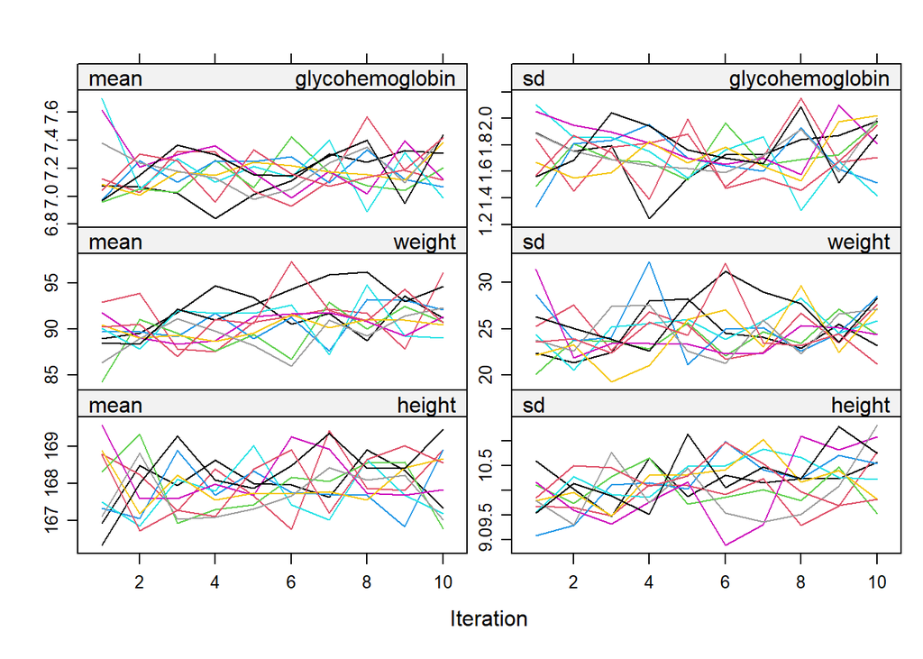

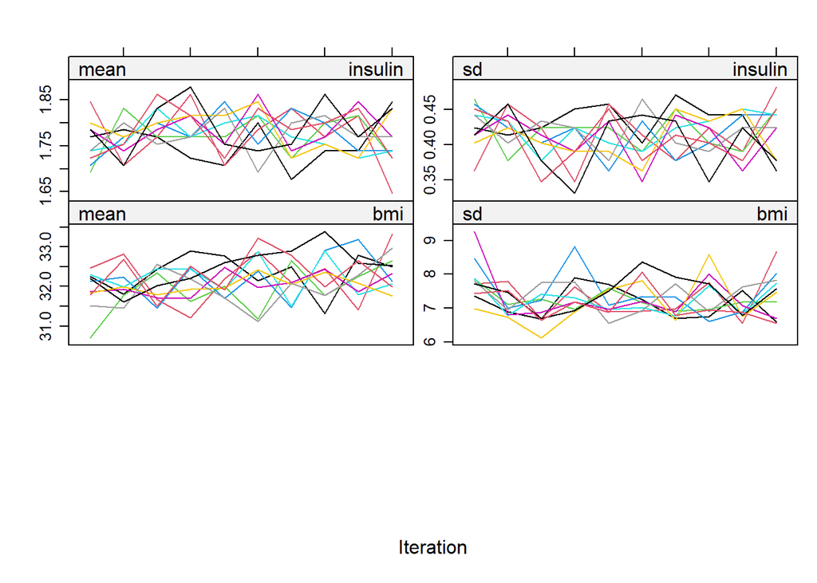

```r
#получим матрицу предикторов
tmp_imp <- mice(
    data, m = 1, maxit = 0, printFlag = FALSE, seed = 29094
)

#зададим пассивную импутацию для ИМТ
my_methods <- tmp_imp$method
my_methods["bmi"] <- "~ I(weight / (height / 100)^2)"

# исключим восполение переменных за счет ИМТ
my_pred_mat <- tmp_imp$predictorMatrix
my_pred_mat[c("height", "weight"), "bmi"] <- 0L


# импутация данных с использованием выставленных выше параметров
imp <- mice(
    data, m = 10, maxit = 10, printFlag = FALSE, seed = 29094,
    predictorMatrix = my_pred_mat,
    method = my_methods
)

# диагностика импутации
plot(imp)
```

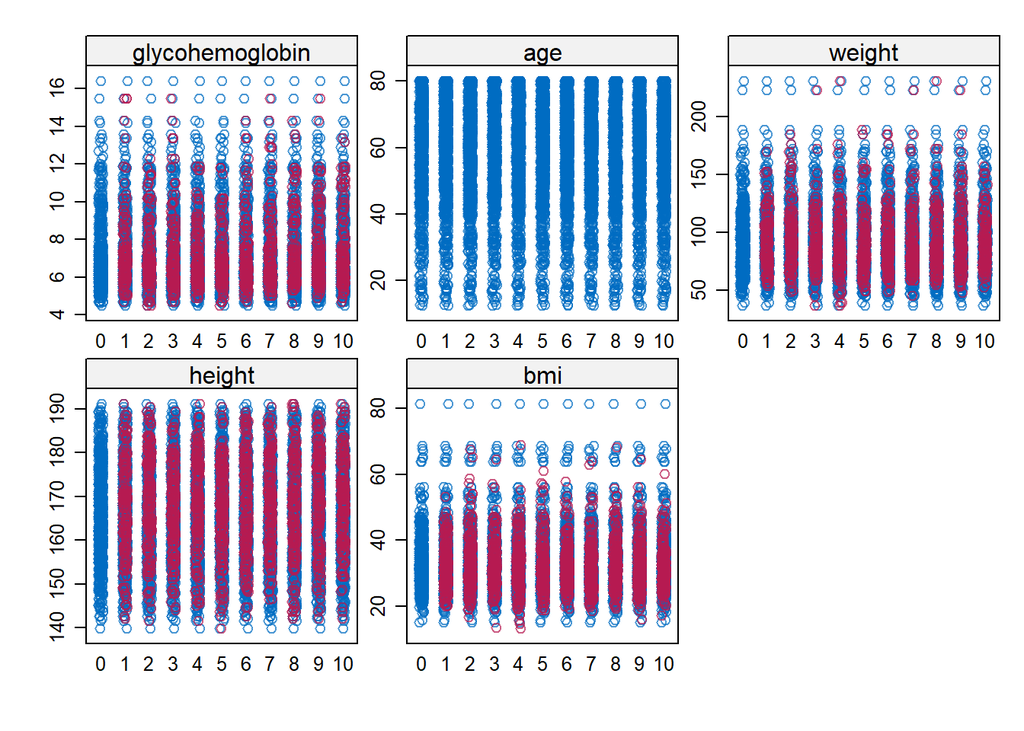

```r
stripplot(imp)
```

Исзодя из графиков диагностики импутации видно: данные при импутации не образуют трендов, распределние импутированных значений соответсвует распределниею исходных значений.

```r
fits <- with(imp, lm(glycohemoglobin ~ bmi*insulin + male + age))

pool(fits) %>%
    broom::tidy() %>%
  as.data.frame() %>%
  mutate(
    across(where(is.numeric), ~ round(., digits = 3))
  ) %>%
  flextable()
```

| term | estimate | std.error | statistic | p.value | b | df | dfcom | fmi | lambda | m | riv | ubar |
| --- | --- | --- | --- | --- | --- | --- | --- | --- | --- | --- | --- | --- |
| (Intercept) | 6.322 | 0.510 | 12.388 | 0.000 | 0.040 | 221.374 | 908 | 0.177 | 0.169 | 10 | 0.204 | 0.216 |
| bmi | 0.009 | 0.013 | 0.716 | 0.474 | 0.000 | 274.260 | 908 | 0.152 | 0.146 | 10 | 0.170 | 0.000 |
| insulin1 | 2.056 | 0.557 | 3.690 | 0.000 | 0.077 | 102.866 | 908 | 0.286 | 0.272 | 10 | 0.373 | 0.226 |
| male1 | 0.262 | 0.117 | 2.244 | 0.026 | 0.002 | 181.633 | 908 | 0.202 | 0.193 | 10 | 0.239 | 0.011 |
| age | -0.013 | 0.004 | -3.053 | 0.003 | 0.000 | 108.674 | 908 | 0.277 | 0.263 | 10 | 0.357 | 0.000 |
| bmi:insulin1 | -0.018 | 0.017 | -1.045 | 0.298 | 0.000 | 101.799 | 908 | 0.287 | 0.273 | 10 | 0.376 | 0.000 |

```r
# 0.009356845 + 1.96 * 0.01306427
# 0.009356845 - 1.96 * 0.01306427
#
# 2.055550479 + 1.96 * 0.55713324
# 2.055550479 - 1.96 * 0.55713324
#
# -0.017748081 + 1.96 * 0.01697809
# -0.017748081 - 1.96 * 0.01697809
```

В результате импутации данных мы получили следующие оценки зависимости уровня гликированного гемоглобина от ИМТ с учетом применения препаратов инсулина и поправкой на пол и возраст:

1. увеличение ИМТ на 1 кг/м^2 статистически не значимо увеличивает уровень гликированного гемоглобина на 0,009% п.п. (95% ДИ [-0.016; 0.034], р-значение = 0.47).
2. Прием препаратов инсулина статистически значимо повышает уровень гликированного гемоглобина 2,05% п.п. (95% ДИ [0.96; 3.15], р-значение = 3.6 × 10⁻⁴).
3. наблюдается статистически незначимый эффект группы: эффект имт статистически не значимо различается между группами пациентов принимающих и не принимаюх инсулин на -0,018% п.п. (95% ДИ [-0.051; 0.015], р-значение = 0.298).

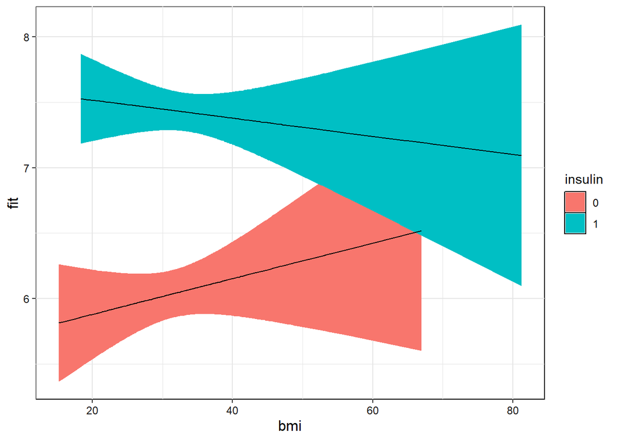

```r
fits2 <- with(imp, lm(glycohemoglobin ~ bmi*insulin))

preds <- map(
    getfit(fits2), \(x) predict(x, se.fit = TRUE)
)

preds_point <- sapply(preds, \(x) x[["fit"]])
preds_var <- sapply(preds, \(x) x[["se.fit"]]^2)

map(seq_len(nrow(preds_point)), function(i) {
    pooled <- pool.scalar(Q = preds_point[i, ], U = preds_var[i, ])
    c("fit" = pooled[["qbar"]],
      "se.fit" = sqrt(pooled[["t"]]))
}) %>%
    reduce(bind_rows) %>%
    bind_cols(data) %>%
  drop_na(insulin, bmi) %>%
  arrange(insulin, bmi) %>%
    ggplot(aes(bmi, fit,  fill = insulin)) +
    geom_ribbon (aes(ymin = fit - 1.96* se.fit,
                     ymax = fit + 1.96* se.fit))+
    geom_line()
```